# Hw_5

Valeriia

07 06 2020

```r
library(cluster)
library(fpc)
library(factoextra)
library(dplyr)
library(FactoMineR)
library(ggplot2)
library(MASS)
```

K-means.

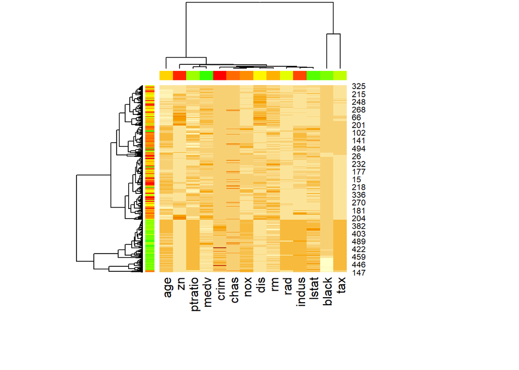

```r
data(Boston)
x <-  as.matrix(Boston) # Сначала посмотрим хитмап, как влияют данные друг на друга
rc <- rainbow(nrow(x), start = 0, end = .3)
cc <- rainbow(ncol(x), start = 0, end = .3)
hv <- heatmap(x,  scale = "col",  RowSideColors = rc,
           ColSideColors = cc, margins = c(10,10),
           cexCol = 1.5, cexRow = 1)
```

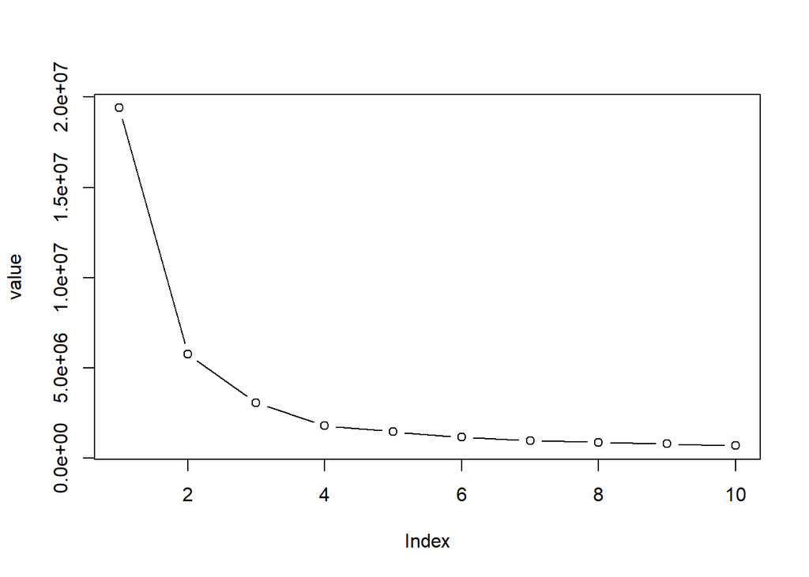

```r
value <- rep(0,10) # Определим количество к, оптимально3
set.seed(3)
for (i in 1:10){
  value[i] <- kmeans(Boston, i, nstart = 20)$tot.withinss
}
plot(value, type = "b")
```

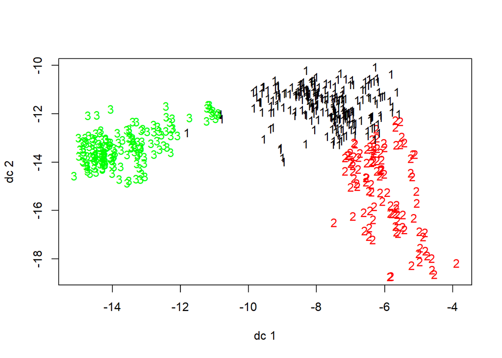

```r
df.stand <- scale(Boston)
clus <- kmeans(df.stand, centers = 3, nstart = 20)
plotcluster(Boston, clus$cluster)
```

```r
set.seed(3)
boston <- as.data.frame(Boston)
clusters <- kmeans(df.stand, 3)
boston$cluster <- clusters$cluster
aggregate(data = boston, medv ~ cluster, mean) #Посмотрим разделение на примере цены за квартиру
```

| cluster | medv |
| --- | --- |
| 1 | 32.34320 |
| 2 | 21.62963 |
| 3 | 16.28303 |

PAM method. Метод PAM во многом идентичен алгоритму k средних за исключением того, что вместо вычисления центроидов осуществляется поиск k наиболее представительных объектов (или медоидов) среди анализируемых наблюдений. Внутрикластерный разброс оценивается при этом по манхэттенскому, а не евклидовому расстоянию, как в kmeans().

```
##   cluster size ave.sil.width
## 1       1  133          0.24
## 2       2  216          0.21
## 3       3  157          0.25
```

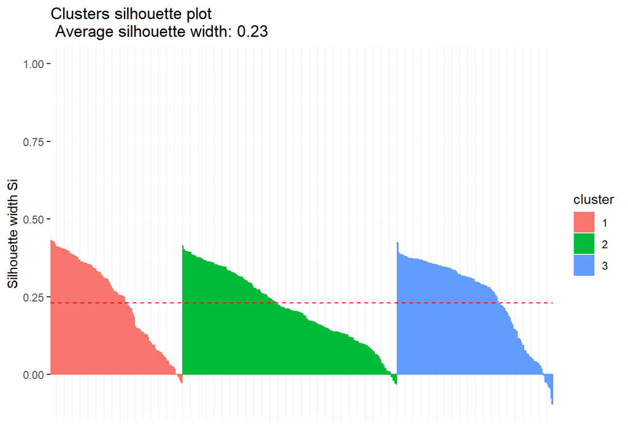

```r
set.seed(123)
df.stand <- as.data.frame(scale(Boston))
k.pam <- pam(df.stand, k = 3)
fviz_silhouette(silhouette(k.pam))
```

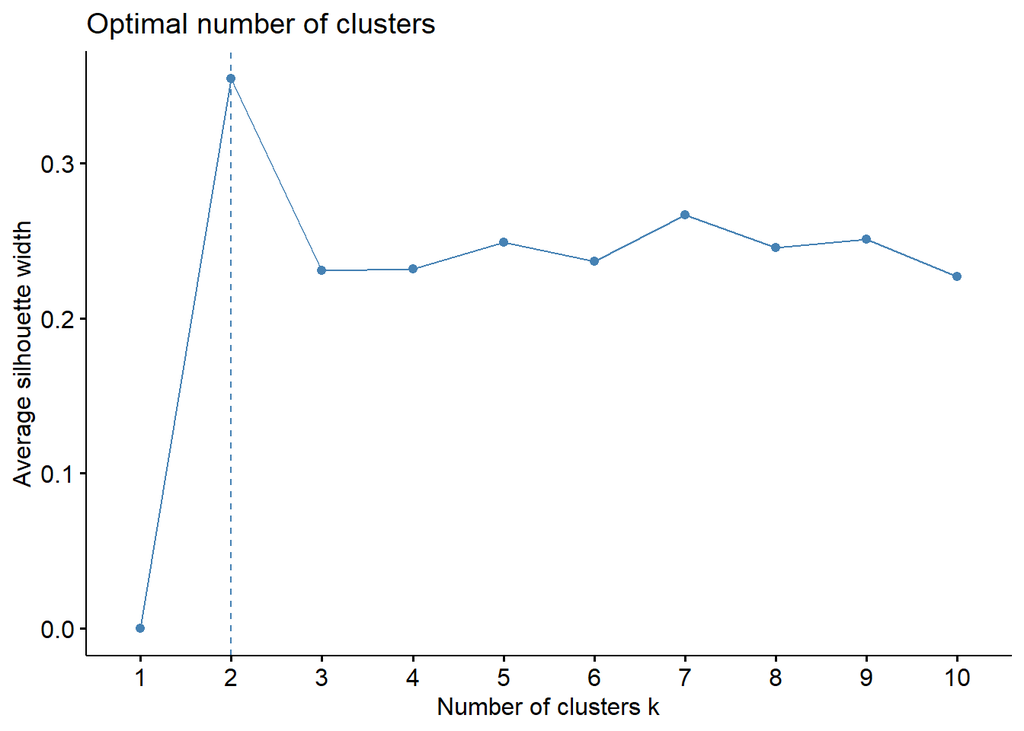

```r
fviz_nbclust(df.stand, pam, method = "silhouette") #Оптимальное кол-во кластеров 2
```

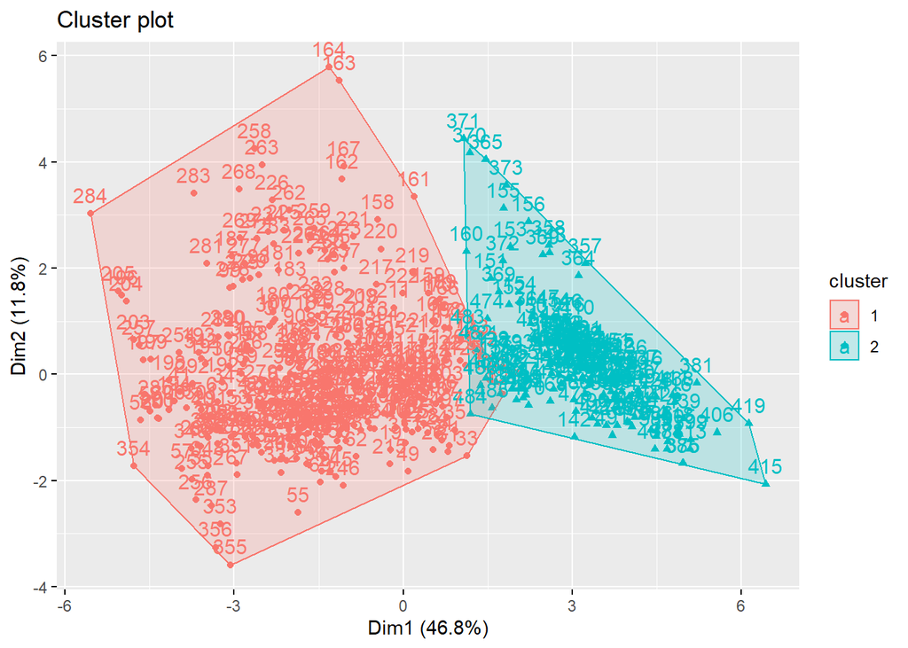

```r
fviz_cluster(pam(df.stand, 2), stand = FALSE)
```

Hierarchical

алгоритм средней связи (average linkage clustering) на каждом следующем шаге объединяет два ближайших кластера, рассчитывая среднюю арифметическую дистанцию между всеми парами объектов. К алгоритму средней связи естественно сразу добавить еще два со взаимно противоположными тенденциями: алгоритм одиночной связи, или “ближайшего соседа” (single linkage clustering), когда расстояние между кластерами оценивается как минимальное из дистанций между парами объектов, один из которых входит в первый кластер, а другой - во второй; и алгоритм полной связи или “дальнего соседа” (complete linkage clustering), когда вычисляется расстояние между наиболее удаленными объектами.

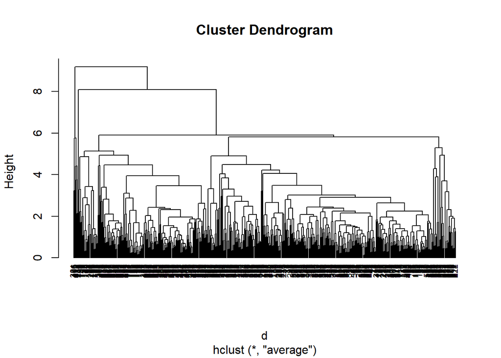

```r
d <- dist(df.stand, method = "euclidean")
# Параметр hang=-1  выравнивает метки
plot(hclust(d, method = "average" ), cex = 0.7, hang = -1)
```

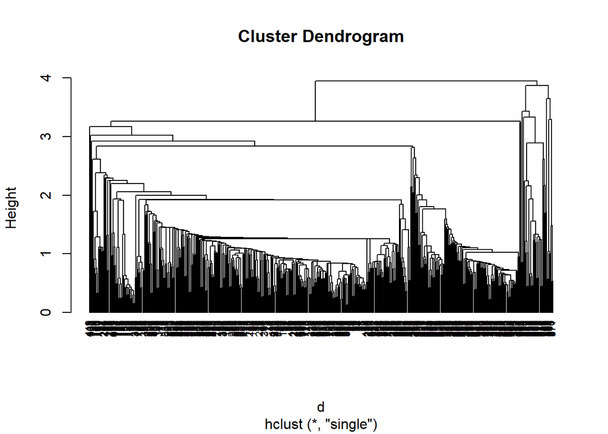

```r
plot(hclust(d, method = "single" ), cex = 0.7, hang = -1)
```

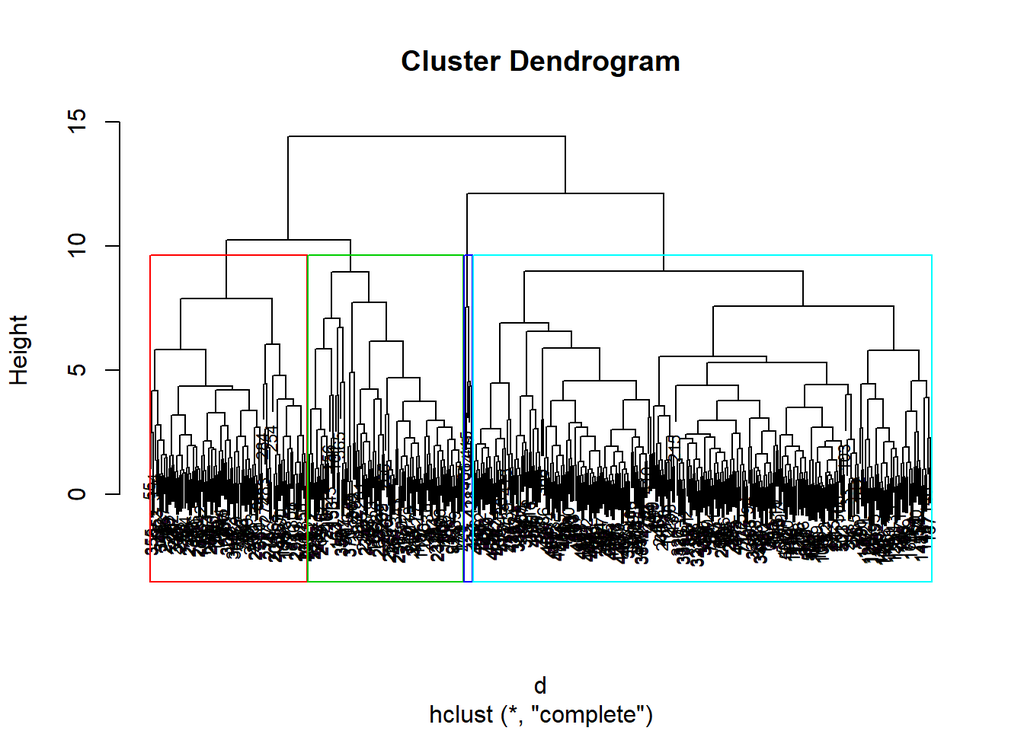

```r
res.hc <- hclust(d, method = "complete" )
grp <- cutree(res.hc, k = 3)  # Разрезание дерева на 3 группы
plot(res.hc, cex = 0.7)
rect.hclust(res.hc, k = 4, border = 2:5)
```

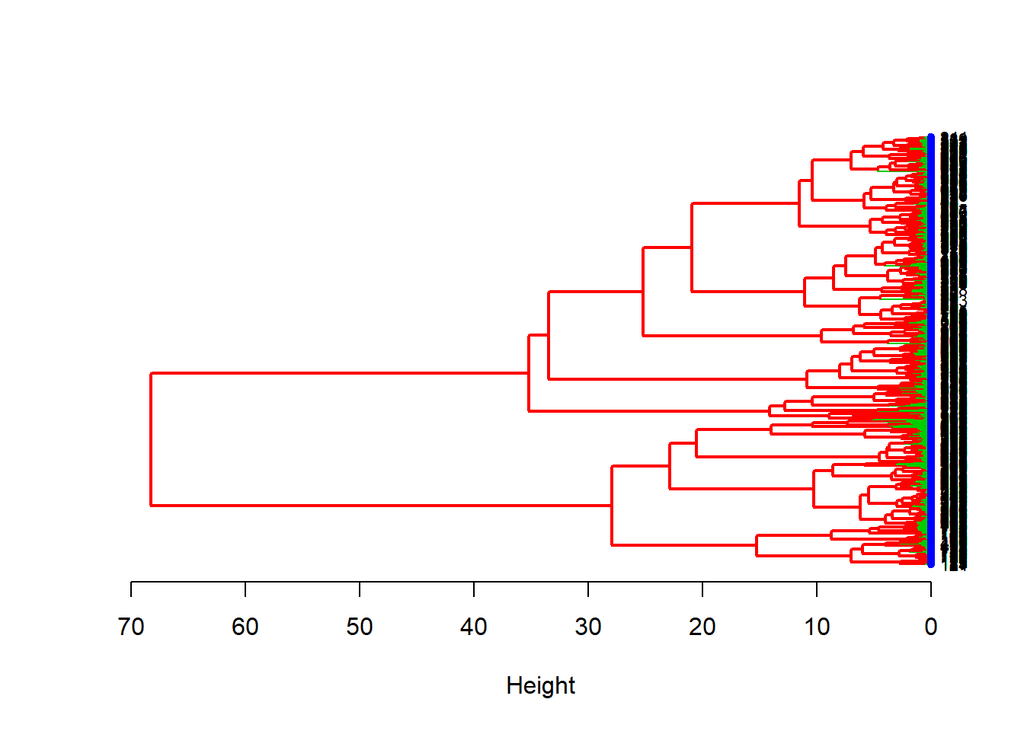

```r
hcd <- as.dendrogram(hclust(d, method = "ward.D2" )) #метод Уорда
nodePar <- list(lab.cex = 0.7, pch = c(NA, 19), cex = 0.7, col = "blue")
plot(hcd,  xlab = "Height", nodePar = nodePar, horiz = TRUE,
     edgePar = list(col = 2:3, lwd = 2:1))
```

Для количественной оценки различий между вариантами кластеризации могут быть использованы кофенетическая корреляция (cophenetic correlation) или различные ранговые индексы. Кофенетическая дистанция определяет расстояние между двумя объектами на дендрограмме и отражает уровень внутригрупповых различий, при котором эти объекты были впервые объединены в один кластер (Ким и др., 1989). Все возможные пары таких дистанций образуют апостериорную матрицу расстояний между объектами по результатам кластеризации. Кофенетическая корреляция вычисляется как линейный коэффициент корреляции Пирсона (или ранговый коэффициент Спирмена) между всеми элементами двух таких матриц:

```r
library(dendextend)
```

```r
# Создаем множество дендрограмм для сравнения
dend1 <- d %>% hclust("com") %>% as.dendrogram
dend2 <- d %>% hclust("single") %>% as.dendrogram
dend3 <- d %>% hclust("ave") %>% as.dendrogram
dend4 <- d %>% hclust("centroid") %>% as.dendrogram
dend5 <- d %>% hclust("ward.D2") %>% as.dendrogram

# Создаем список дендрограмм и корреляционную матрицу
dend_list <- dendlist("Complete" = dend1, "Single" = dend2,
     "Average" = dend3, "Centroid" = dend4, "Ward.D2" = dend5)
cors <- cor.dendlist(dend_list)
round(cors, 2)
```

```
##          Complete Single Average Centroid Ward.D2
## Complete     1.00   0.30    0.40     0.25    0.38
## Single       0.30   1.00    0.75     0.64    0.58
## Average      0.40   0.75    1.00     0.74    0.78
## Centroid     0.25   0.64    0.74     1.00    0.46
## Ward.D2      0.38   0.58    0.78     0.46    1.00
```

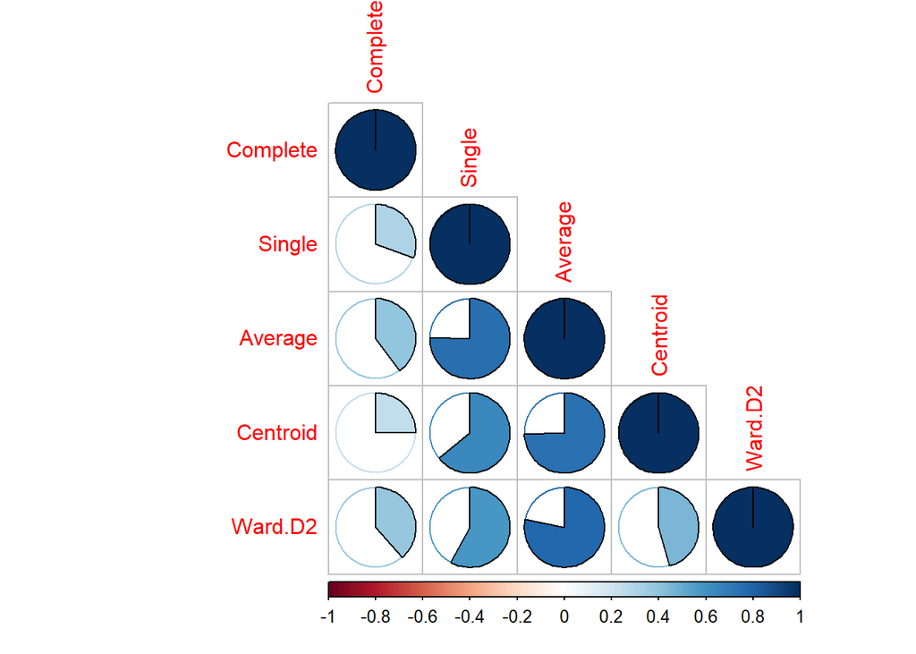

```r
library(corrplot) # изображение корреляционной матрицы
corrplot(cors, "pie", "lower")
```

Иерархическая кластеризация на главные компоненты

В среде R кластеризация на главные компоненты реализована в пакете FactoMineR и состоит из двух шагов. На первом этапе функцией РСА() выполняется обычный анализ главных компонент и выбирается их число. Далее функция HCPC() использует эти результаты и строит иерархическую кластеризацию. При этом используется метод Уорда, который, как и анализ главных компонент, основан на анализе многомерной дисперсии (inertia).

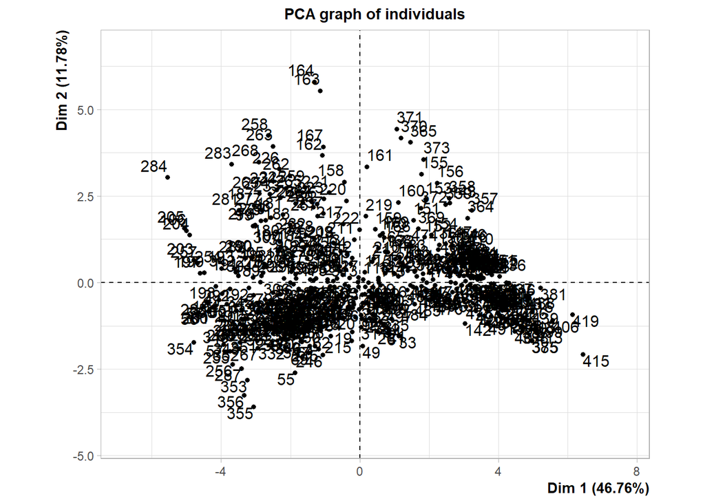

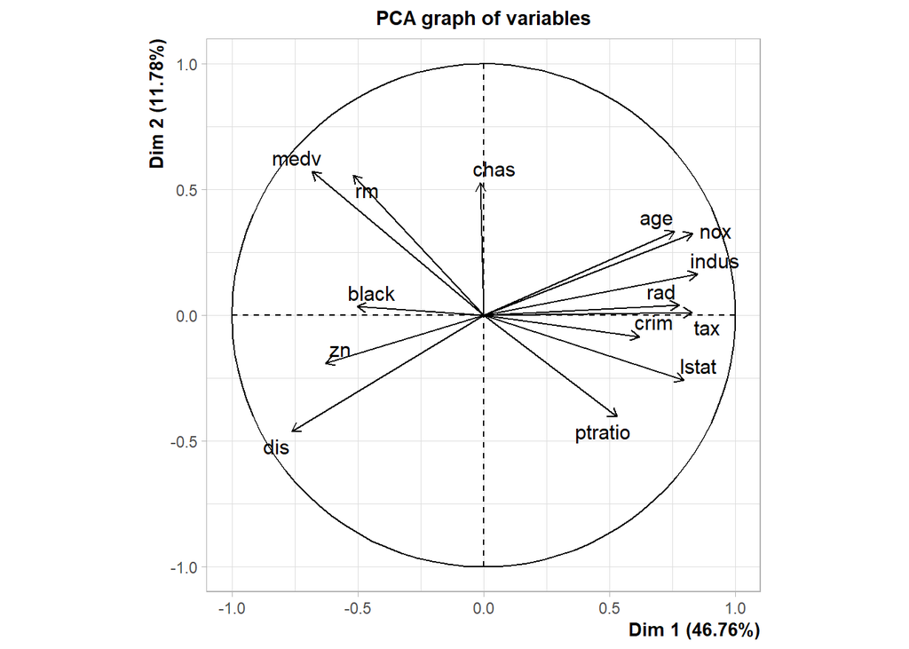

```r
df.scale <- scale(Boston)
res.pca <- PCA(df.scale, ncp = 5, graph = TRUE)
```

```r
get_eig(res.pca)
```

```
##        eigenvalue variance.percent cumulative.variance.percent
## Dim.1  6.54598958       46.7570684                    46.75707
## Dim.2  1.64953191       11.7823708                    58.53944
## Dim.3  1.34890592        9.6350423                    68.17448
## Dim.4  0.88653987        6.3324276                    74.50691
## Dim.5  0.85089944        6.0778531                    80.58476
## Dim.6  0.66001077        4.7143627                    85.29912
## Dim.7  0.53541080        3.8243629                    89.12349
## Dim.8  0.40307658        2.8791184                    92.00261
## Dim.9  0.27726358        1.9804542                    93.98306
## Dim.10 0.25225744        1.8018389                    95.78490
## Dim.11 0.21279025        1.5199304                    97.30483
## Dim.12 0.18298750        1.3070536                    98.61188
## Dim.13 0.13400970        0.9572121                    99.56910
## Dim.14 0.06032666        0.4309047                   100.00000
```

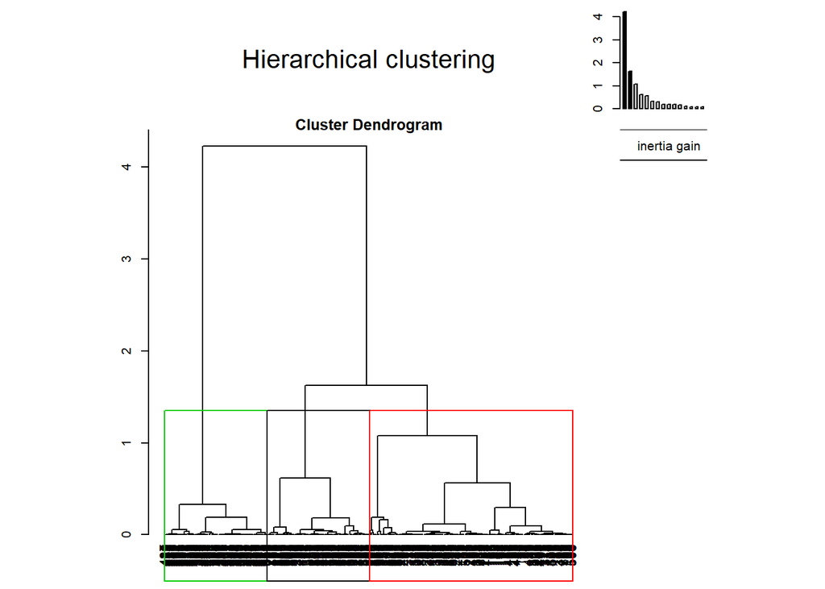

```r
res.hcpc <- HCPC(res.pca, graph = FALSE)
plot(res.hcpc, choice = "tree")
```

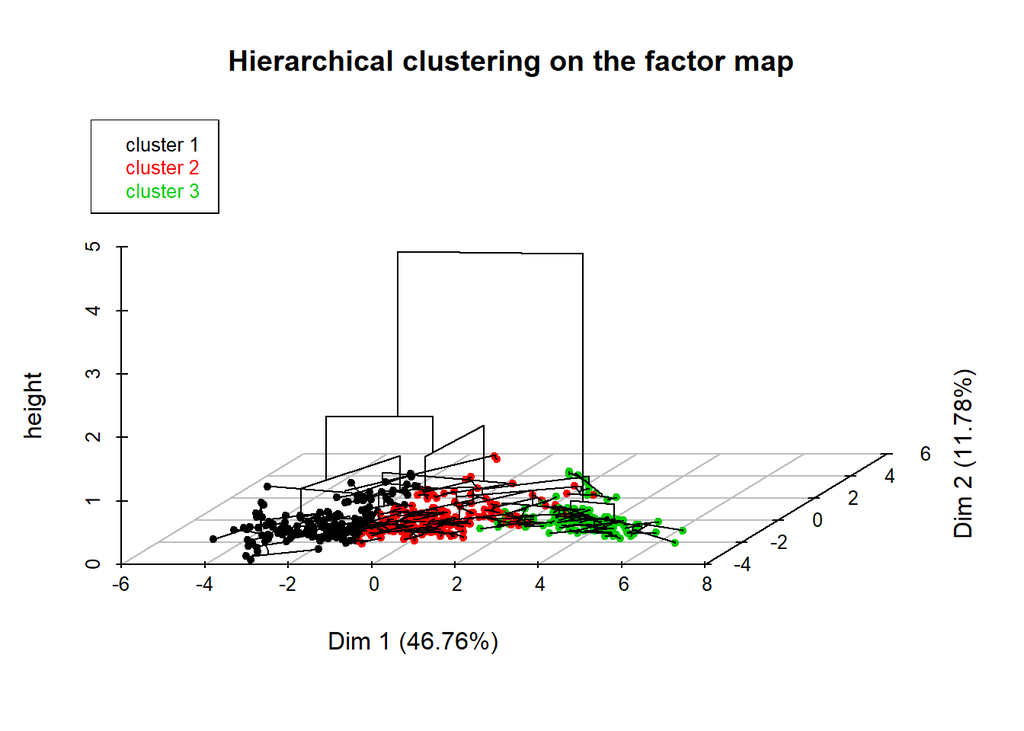

```r
plot(res.hcpc, choice = "3D.map", ind.names = FALSE)
```

PCA

```r
boston_pca <- boston[,-c(14,15)]
boston_pca <- scale(boston_pca)
pca <- prcomp(x = boston_pca, center = TRUE, scale = TRUE)
pca
```

```
## Standard deviations (1, .., p=13):
##  [1] 2.4752472 1.1971947 1.1147272 0.9260535 0.9136826 0.8108065 0.7316803
##  [8] 0.6293626 0.5262541 0.4692950 0.4312938 0.4114644 0.2520104
##
## Rotation (n x k) = (13 x 13):
##                  PC1         PC2         PC3         PC4          PC5
## crim     0.250951397 -0.31525237  0.24656649 -0.06177071  0.082156919
## zn      -0.256314541 -0.32331290  0.29585782 -0.12871159  0.320616987
## indus    0.346672065  0.11249291 -0.01594592 -0.01714571 -0.007811194
## chas     0.005042434  0.45482914  0.28978082 -0.81594136  0.086530945
## nox      0.342852313  0.21911553  0.12096411  0.12822614  0.136853557
## rm      -0.189242570  0.14933154  0.59396117  0.28059184 -0.423447195
## age      0.313670596  0.31197778 -0.01767481  0.17520603  0.016690847
## dis     -0.321543866 -0.34907000 -0.04973627 -0.21543585  0.098592247
## rad      0.319792768 -0.27152094  0.28725483 -0.13234996 -0.204131621
## tax      0.338469147 -0.23945365  0.22074447 -0.10333509 -0.130460565
## ptratio  0.204942258 -0.30589695 -0.32344627 -0.28262198 -0.584002232
## black   -0.202972612  0.23855944 -0.30014590 -0.16849850 -0.345606947
## lstat    0.309759840 -0.07432203 -0.26700025 -0.06941441  0.394561129
##                 PC6          PC7          PC8         PC9         PC10
## crim    -0.21965961  0.777607207 -0.153350477  0.26039028 -0.019369130
## zn      -0.32338810 -0.274996280  0.402680309  0.35813749 -0.267527234
## indus   -0.07613790 -0.339576454 -0.173931716  0.64441615  0.363532262
## chas     0.16749014  0.074136208  0.024662148 -0.01372777  0.006181836
## nox     -0.15298267 -0.199634840 -0.080120560 -0.01852201 -0.231056455
## rm       0.05926707  0.063939924  0.326752259  0.04789804  0.431420193
## age     -0.07170914  0.116010713  0.600822917 -0.06756218 -0.362778957
## dis      0.02343872 -0.103900440  0.121811982 -0.15329124  0.171213138
## rad     -0.14319401 -0.137942546 -0.080358311 -0.47089067 -0.021909452
## tax     -0.19293428 -0.314886835 -0.082774347 -0.17656339  0.035168348
## ptratio  0.27315330  0.002323869  0.317884202  0.25442836 -0.153430488
## black   -0.80345454  0.070294759  0.004922915 -0.04489802  0.096515117
## lstat   -0.05321583  0.087011169  0.424352926 -0.19522139  0.600711409
##                PC11         PC12         PC13
## crim    -0.10964435 -0.086761070  0.045952304
## zn       0.26275629  0.071425278 -0.080918973
## indus   -0.30316943  0.113199629 -0.251076540
## chas     0.01392667  0.003982683  0.035921715
## nox      0.11131888 -0.804322567  0.043630446
## rm       0.05316154 -0.152872864  0.045567096
## age     -0.45915939  0.211936074 -0.038550683
## dis     -0.69569257 -0.390941129 -0.018298538
## rad      0.03654388  0.107025890 -0.633489720
## tax     -0.10483575  0.215191126  0.720233448
## ptratio  0.17450534 -0.209598826  0.023398052
## black    0.01927490 -0.041723158 -0.004463073
## lstat    0.27138243 -0.055225960  0.024431677
```

```r
summary(pca)
```

```
## Importance of components:
##                           PC1    PC2     PC3     PC4     PC5     PC6     PC7
## Standard deviation     2.4752 1.1972 1.11473 0.92605 0.91368 0.81081 0.73168
## Proportion of Variance 0.4713 0.1103 0.09559 0.06597 0.06422 0.05057 0.04118
## Cumulative Proportion  0.4713 0.5816 0.67713 0.74310 0.80732 0.85789 0.89907
##                            PC8    PC9    PC10    PC11    PC12    PC13
## Standard deviation     0.62936 0.5263 0.46930 0.43129 0.41146 0.25201
## Proportion of Variance 0.03047 0.0213 0.01694 0.01431 0.01302 0.00489
## Cumulative Proportion  0.92954 0.9508 0.96778 0.98209 0.99511 1.00000
```

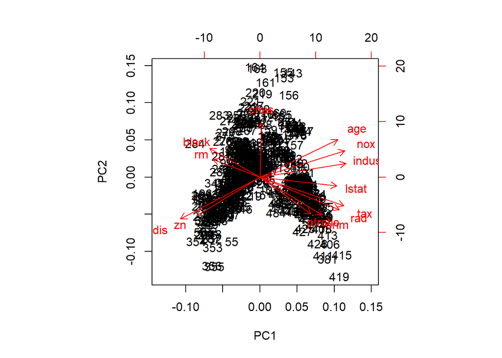

```r
biplot(pca)
```